# $\alpha$策略是可以用的

就A初赛来说，就是提交后，系统会用我们选择的20支股票，t=0，t=半年后，两个时间点的价格，算加权平均收益率，谁高谁获胜。 其实就是找到20-50个股票，最大化，组合收益率。 在期间，我们可以任意修改这些股票的类别，或者增加，但是不能超过50个。 假设系统最佳组合有30个股票，且是唯一解，我们就是尽量通过方法，选出30个，还要跟30每个都一样。

用return做为Y变量。合成一个指数。 可以 然后再把每只股票做一个回归 一般金融上来说 最好factors在 3个或以上 就基本可以很显著了。 嗯，相当于我合成指数的时候，我可以聚出三个，三个指数， 700 合成是三个指数，按照三因子模型，里面那个不同特性 这个我具体忘了定义了。

我等明天群里有人回复了，确定这个方向可以搞了， 我在搞指数，三个，然后开始预测alpha，最后选股。

# 比赛要求

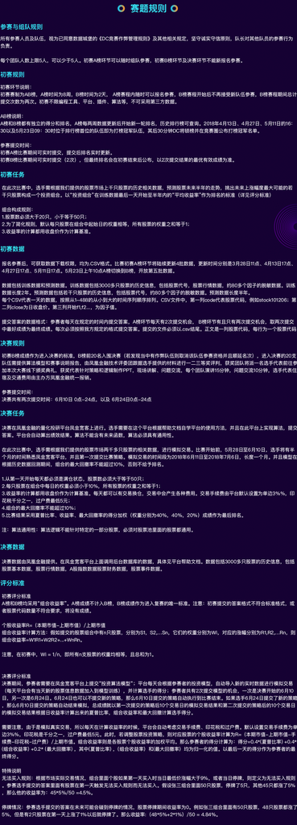

# 参考paper

- 王淑燕, 曹正凤, 陈铭芷. 随机森林在量化选股中的应用研究[J]. 运筹与管理, 2016, 25(3):163-168.
- 谢合亮, 胡迪. 多因子量化模型在投资组合中的应用——基于LASSO与Elastic Net的比较研究[J]. 统计与信息论坛, 2017, 32(10):36-42.
- 周渐. 基于SVM算法的多因子选股模型实证研究[D]. 浙江工商大学, 2017.